# Project 1

Justin Herman

8/29/2019

**Principles of Data Visualization and Introduction to ggplot2**

I have provided you with data about the 5,000 fastest growing companies in the US, as compiled by Inc. magazine. lets read this in:

```r
inc <- read.csv("https://raw.githubusercontent.com/charleyferrari/CUNY_DATA_608/master/module1/Data/inc5000_data.csv", header= TRUE)
```

And lets preview this data:

```r
head(inc)
```

```
##   Rank                         Name Growth_Rate   Revenue
## 1    1                         Fuhu      421.48 1.179e+08
## 2    2        FederalConference.com      248.31 4.960e+07
## 3    3                The HCI Group      245.45 2.550e+07
## 4    4                      Bridger      233.08 1.900e+09
## 5    5                       DataXu      213.37 8.700e+07
## 6    6 MileStone Community Builders      179.38 4.570e+07
##                       Industry Employees         City State
## 1 Consumer Products & Services       104   El Segundo    CA
## 2          Government Services        51     Dumfries    VA
## 3                       Health       132 Jacksonville    FL
## 4                       Energy        50      Addison    TX
## 5      Advertising & Marketing       220       Boston    MA
## 6                  Real Estate        63       Austin    TX
```

```r
summary(inc)
```

```
##       Rank                          Name       Growth_Rate
##  Min.   :   1   (Add)ventures         :   1   Min.   :  0.340
##  1st Qu.:1252   @Properties           :   1   1st Qu.:  0.770
##  Median :2502   1-Stop Translation USA:   1   Median :  1.420
##  Mean   :2502   110 Consulting        :   1   Mean   :  4.612
##  3rd Qu.:3751   11thStreetCoffee.com  :   1   3rd Qu.:  3.290
##  Max.   :5000   123 Exteriors         :   1   Max.   :421.480
##                 (Other)               :4995
##     Revenue                                  Industry      Employees
##  Min.   :2.000e+06   IT Services                 : 733   Min.   :    1.0
##  1st Qu.:5.100e+06   Business Products & Services: 482   1st Qu.:   25.0
##  Median :1.090e+07   Advertising & Marketing     : 471   Median :   53.0
##  Mean   :4.822e+07   Health                      : 355   Mean   :  232.7
##  3rd Qu.:2.860e+07   Software                    : 342   3rd Qu.:  132.0
##  Max.   :1.010e+10   Financial Services          : 260   Max.   :66803.0
##                      (Other)                     :2358   NA's   :12
##             City          State
##  New York     : 160   CA     : 701
##  Chicago      :  90   TX     : 387
##  Austin       :  88   NY     : 311
##  Houston      :  76   VA     : 283
##  San Francisco:  75   FL     : 282
##  Atlanta      :  74   IL     : 273
##  (Other)      :4438   (Other):2764
```

Think a bit on what these summaries mean. Use the space below to add some more relevant non-visual exploratory information you think helps you understand this data: + Extra things to look at psych describe package has standard deviation skew and kurtosis + Hmisc has corr to look for colinearity

```r
library(psych)
library(corrplot)
library(Hmisc)
##
psych::describe(inc)
```

```
##             vars    n        mean           sd    median     trimmed
## Rank           1 5001     2501.64      1443.51 2.502e+03     2501.73
## Name*          2 5001     2501.00      1443.81 2.501e+03     2501.00
## Growth_Rate    3 5001        4.61        14.12 1.420e+00        2.14
## Revenue        4 5001 48222535.49 240542281.14 1.090e+07 17334966.26
## Industry*      5 5001       12.10         7.33 1.300e+01       12.05
## Employees      6 4989      232.72      1353.13 5.300e+01       81.78
## City*          7 5001      732.00       441.12 7.610e+02      731.74
## State*         8 5001       24.80        15.64 2.300e+01       24.44
##                     mad     min        max      range  skew kurtosis
## Rank            1853.25 1.0e+00 5.0000e+03 4.9990e+03  0.00    -1.20
## Name*           1853.25 1.0e+00 5.0010e+03 5.0000e+03  0.00    -1.20
## Growth_Rate        1.22 3.4e-01 4.2148e+02 4.2114e+02 12.55   242.34
## Revenue     10674720.00 2.0e+06 1.0100e+10 1.0098e+10 22.17   722.66
## Industry*          8.90 1.0e+00 2.5000e+01 2.4000e+01 -0.10    -1.18
## Employees         53.37 1.0e+00 6.6803e+04 6.6802e+04 29.81  1268.67
## City*            604.90 1.0e+00 1.5190e+03 1.5180e+03 -0.04    -1.26
## State*            19.27 1.0e+00 5.2000e+01 5.1000e+01  0.12    -1.46
##                     se
## Rank             20.41
## Name*            20.42
## Growth_Rate       0.20
## Revenue     3401441.44
## Industry*         0.10
## Employees        19.16
## City*             6.24
## State*            0.22
```

```r
cor(inc[,c(3,4,6)])
```

```
##             Growth_Rate     Revenue Employees
## Growth_Rate 1.000000000 0.006304135        NA
## Revenue     0.006304135 1.000000000        NA
## Employees            NA          NA         1
```

## Question 1

Create a graph that shows the distribution of companies in the dataset by State (ie how many are in each state). There are a lot of States, so consider which axis you should use. This visualization is ultimately going to be consumed on a ‘portrait’ oriented screen (ie taller than wide), which should further guide your layout choices.

```r
library(usmap)
```

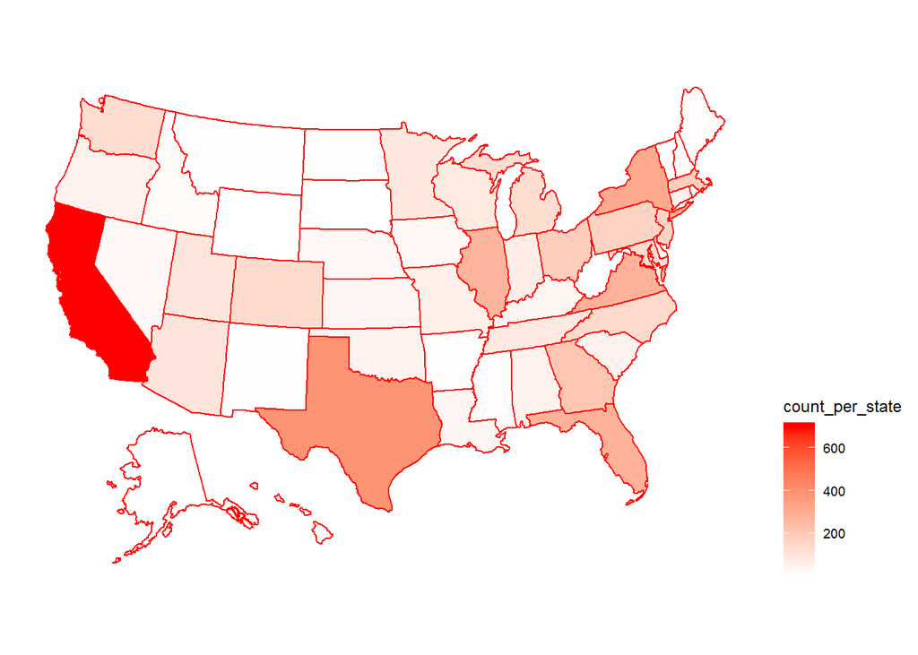

```r
library(ggplot2)
#library(albersusa) # https://gitlab.com/hrbrmstr/albersusa / https://github.com/hrbrmstr/albersusa
library(ggplot2)
library(sp)
library(tidyverse)
inc <- inc %>%
    mutate(state=as.character(State),
           city=as.character(City))
map_df <- inc %>%
    group_by(state) %>%
    summarise(count_per_state=length(Name)) %>%
    ungroup()


plot_usmap(data = map_df, values = 'count_per_state', lines = "red") +
  scale_fill_continuous(
    low = "white", high = "red", name = "count_per_state", label = scales::comma
  ) + theme(legend.position = "right")
```

```r
library(ggmap)
```

```r
## use google api to convert cities into lat/long
## Due to costs I load in csv from query call
api <- readLines("E:\\Google_api.txt")
register_google(key = api)
locations_df2 <-read_csv("geo_locations.csv")
locations_df2 <- locations_df2 %>%
    select(geo_state=state,city=City,lon,lat)

joined_locations <- plyr::join(inc,locations_df2,'city')

###Something went wrong with join, we have over 100k rows
### first step, drop duplicates
joined_locations <- unique(joined_locations)

## now were down to 5900, lets see two " nearly identical rows"
joined_locations[4,]==joined_locations[5,]
```

```
##    Rank Name Growth_Rate Revenue Industry Employees City State state city
## 32 TRUE TRUE        TRUE    TRUE     TRUE      TRUE TRUE  TRUE  TRUE TRUE
##    geo_state  lon  lat
## 32     FALSE TRUE TRUE
```

```r
## get rid of mismatches, google returned multiple when city could be in multiple states.
## Easy fix I just said drop any row where google state is different from dataset state
joined_locations <- joined_locations %>%
    filter(geo_state==state)

## print dim
dim(joined_locations)
```

```
## [1] 5001   13
```

[figure not shown]

```r
##plot by location with size based on number employees
map<-get_map(location='united states', zoom=4, maptype = "terrain",
             source='google',color='color')
ggmap(map) + geom_point(
        aes(x=lon, y=lat, show_guide = TRUE),
        data=joined_locations, alpha=.5, na.rm = T)  +
        scale_color_gradient(low="beige", high="blue")
```

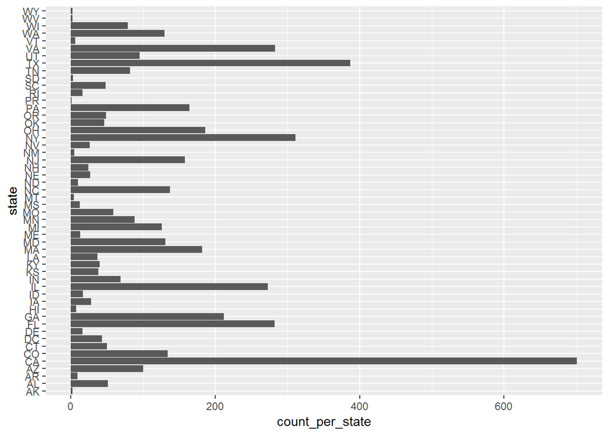

```r
## bar plot
ggplot(data=map_df, aes(x=state, y=count_per_state)) +
  geom_bar(stat="identity")+
    coord_flip()
```

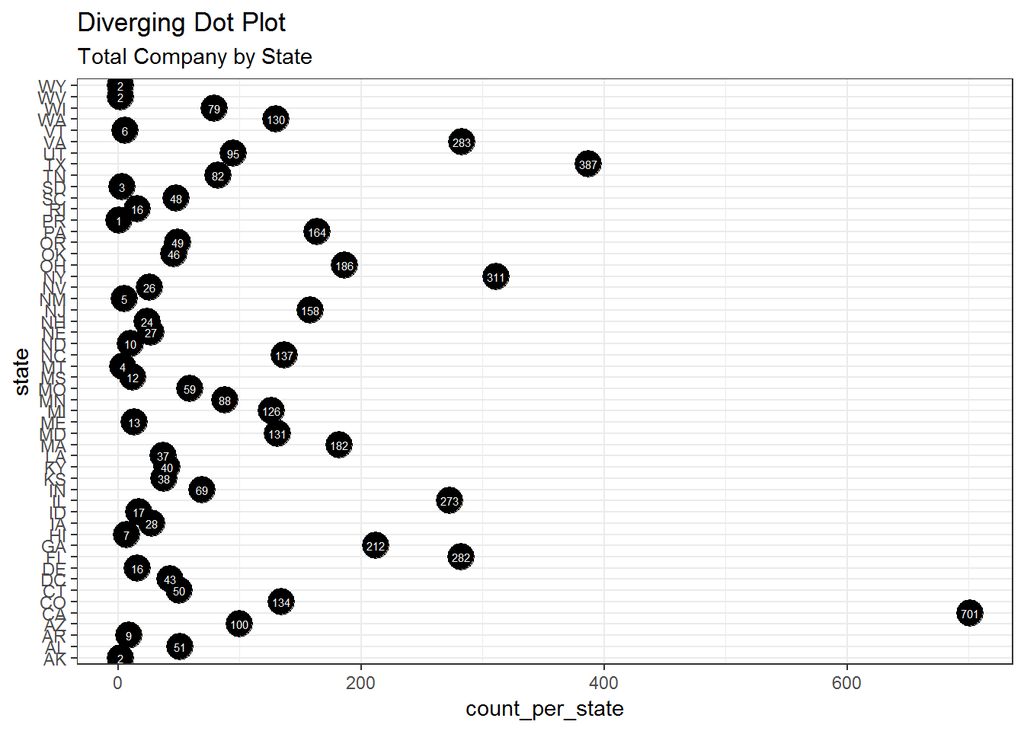

```r
library(ggplot2)
theme_set(theme_bw())

# Plot
ggplot(map_df, aes(x=state, y=count_per_state, label=count_per_state)) +
  geom_point(stat='identity', aes(), size=6)  +
  scale_color_manual(name="Mileage",
                     labels = c("Above Average", "Below Average"),
                     values = c("above"="#00ba38", "below"="#f8766d")) +
  geom_text(color="white", size=2) +
  labs(title="Diverging Dot Plot",
       subtitle="Total Company by State") +
 # ylim(-2.5, 2.5) +
  coord_flip()
```

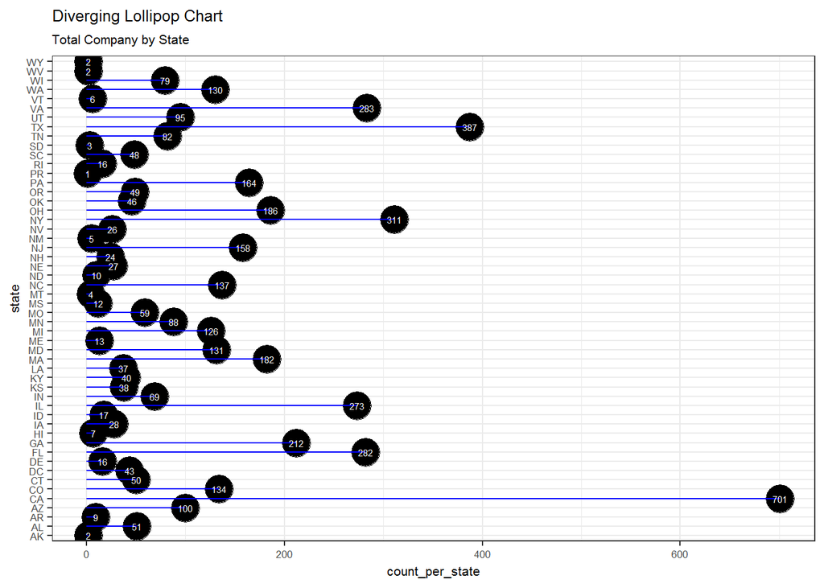

```r
##
ggplot(map_df, aes(x=state, y=count_per_state, label=count_per_state)) +
  geom_point(stat='identity', size=8)  +
  geom_segment(aes(y = 0,
                   x = state,
                   yend = count_per_state,
                   xend = state),
               color = "blue") +
  geom_text(color="white", size=2) +
  labs(title="Diverging Lollipop Chart",
       subtitle="Total Company by State") +
 # ylim(-2.5, 2.5) +
    theme(text = element_text(size=8))+
  coord_flip()
```

## Quesiton 2

Lets dig in on the state with the 3rd most companies in the data set. Imagine you work for the state and are interested in how many people are employed by companies in different industries. Create a plot that shows the average and/or median employment by industry for companies in this state (only use cases with full data, use R’s `complete.cases()` function.) In addition to this, your graph should show how variable the ranges are, and you should deal with outliers.

```r
## sort df with company count by state and identify state for research
##NY
map_df <- map_df %>%
    arrange(-count_per_state)
map_df[3,]
```

```
## # A tibble: 1 x 2
##   state count_per_state
##   <chr>           <int>
## 1 NY                311
```

```r
NY_df <- inc %>%
    filter(state=="NY")

sort(-NY_df$Employees)
```

```
##   [1] -32000 -10000  -3000  -2280  -2218  -2081  -1271  -1134  -1124  -1000
##  [11]  -1000   -906   -800   -690   -632   -602   -509   -500   -483   -450
##  [21]   -432   -425   -404   -383   -382   -345   -325   -322   -320   -316
##  [31]   -307   -300   -298   -296   -295   -294   -288   -275   -270   -269
##  [41]   -268   -250   -250   -250   -237   -220   -219   -213   -210   -207
##  [51]   -200   -200   -200   -198   -198   -186   -181   -180   -166   -156
##  [61]   -153   -146   -144   -144   -142   -140   -139   -137   -133   -132
##  [71]   -131   -125   -121   -120   -119   -110   -107   -106   -105   -104
##  [81]   -102   -100   -100   -100    -99    -96    -95    -94    -90    -90
##  [91]    -89    -89    -87    -87    -85    -85    -84    -81    -80    -80
## [101]    -80    -79    -77    -75    -75    -75    -74    -73    -73    -70
## [111]    -70    -70    -68    -67    -67    -65    -64    -64    -63    -63
## [121]    -63    -62    -61    -61    -61    -60    -59    -56    -56    -55
## [131]    -55    -55    -55    -54    -53    -52    -51    -51    -51    -51
## [141]    -51    -50    -50    -50    -48    -48    -47    -47    -47    -46
```

[output cut: 17 more lines]

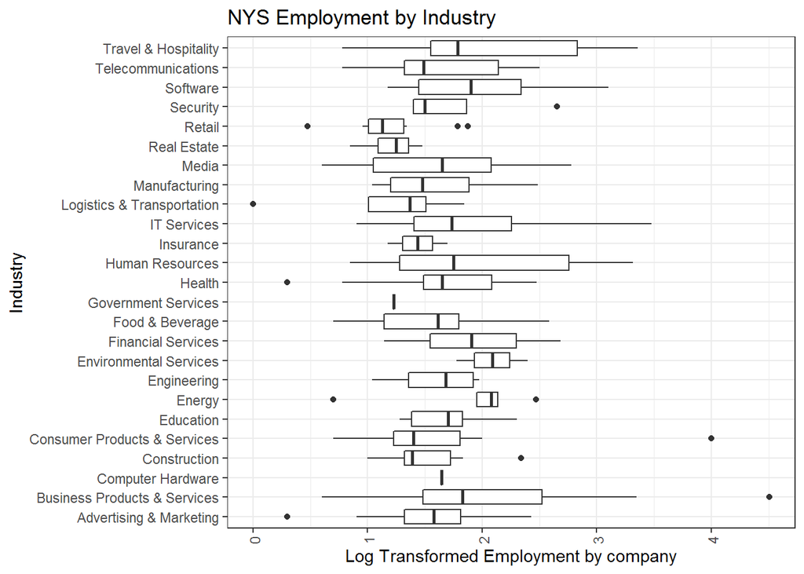

```r
average_employed <- NY_df %>%
    group_by(Industry) %>%
    summarize(average_employed=mean(Employees)) %>%
    mutate(average_employed=round(average_employed,0))


##option 1 without dots
g <- ggplot(NY_df, aes(Industry, log(Employees,10)))
g + geom_boxplot() +
  # geom_dotplot(binaxis='y',
  #              stackdir='center',
  #              dotsize = .5,
  #              fill="red") +
  theme(axis.text.x = element_text(angle=90, vjust=0.6)) +
  labs(title="NYS Employment by Industry",
       x="Industry",
       y="Log Transformed Employment by company")+
  coord_flip()
```

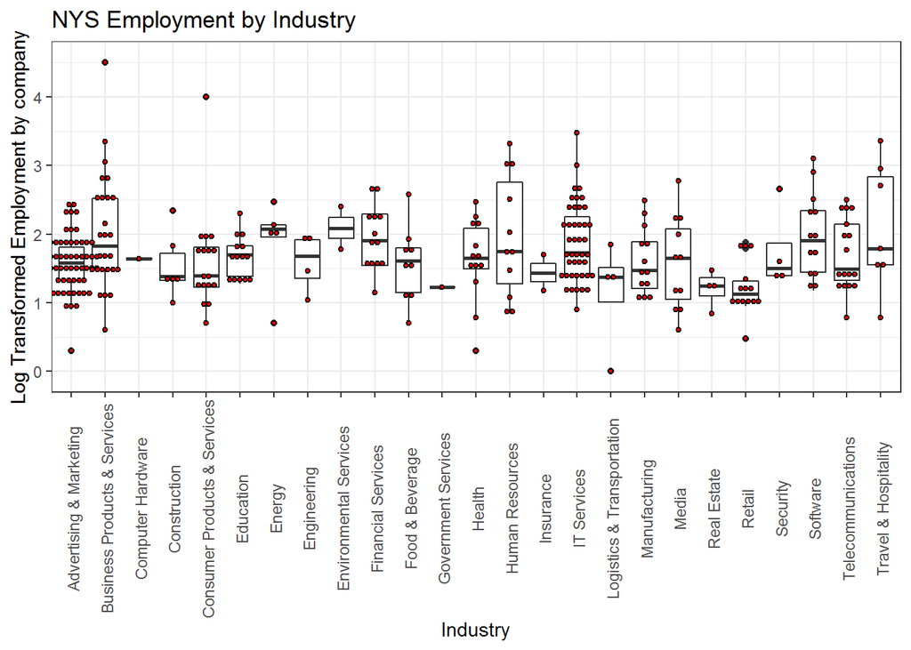

```r
g <- ggplot(NY_df, aes(Industry, log(Employees,10)))
g + geom_boxplot() +
  geom_dotplot(binaxis='y',
               stackdir='center',
               dotsize = .5,
               fill="red") +
  theme(axis.text.x = element_text(angle=90, vjust=0.6)) +
  labs(title="NYS Employment by Industry",
       x="Industry",
       y="Log Transformed Employment by company")
```

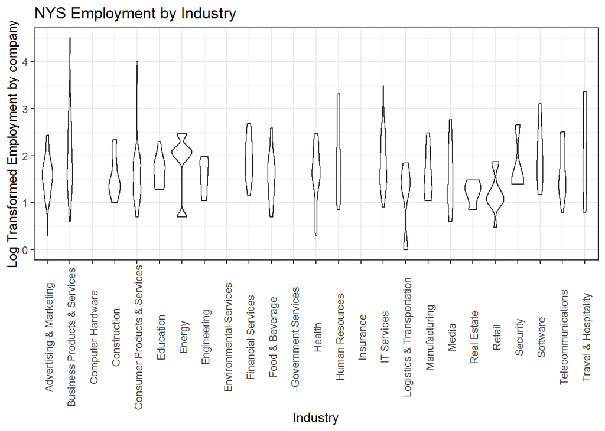

```r
g <- ggplot(NY_df, aes(Industry, log(Employees,10)))
g +  geom_violin()+
  theme(axis.text.x = element_text(angle=90, vjust=0.6)) +
  labs(title="NYS Employment by Industry",
       x="Industry",
       y="Log Transformed Employment by company")
```

## Question 3

Now imagine you work for an investor and want to see which industries generate the most revenue per employee. Create a chart that makes this information clear. Once again, the distribution per industry should be shown.